# Evaluation of Current Management Paradigm for Old Tampa Bay, Florida

Miles Medina, PhD, ECCO Scientific

April 22, 2024

# Contents

Introduction

Data Processing

- Pinellas County water quality data
- Environmental Protection Commission of Hillsborough County (EPC) water quality data
- Tampa Bay Estuary Program nitrogen load estimates

Linear Models

- Nitrogen and chlorophyll
- Chlorophyll and light

Generalized Additive Models (GAMs)

- Nitrogen and chlorophyll
- Chlorophyll and light

References

# Introduction

The current management paradigm for Old Tampa Bay (OTB) is holds that (1) reducing *external nitrogen loads* will reduce chlorophyll a concentrations in the OTB water column, (2) lower *chlorophyll a concentrations* will improve water clarity (e.g., Secchi depth), and (3) improved *water clarity* will stimulate greater *seagrass growth/recovery*. The management paradigm is based on earlier studies that reported significant correlations between each subsequent pair of covariates (e.g., Morrison et al. 1996; Greening & Janicki 2016). This document explores statistical relationships between these pairs at various OTB sub-segments using monthly averaged data at various time lags (zero lag, one-month lag, two-month lag between explanatory variable and response). Analyses were performed in R version 4.3.1 (R Core Team 2023).

The results indicate that linear correlations measured during earlier periods of study continued to hold between approximately 2000 and 2023. However, we also find evidence (GAM results) suggesting that these relationships have varied over time at some OTB sub-segments, with intriguing differences across sub-segments. We conclude that correlation analyses and simple regression models do not reliably capture the potentially synergistic effects of multiple stressors influencing water quality and seagrass abundance.

top

# Data Processing

Water quality and external loading data were assembled by the `./data_proc.R` script. This section processes these data to support the subsequent analyses, including a few basic QA/QC checks.

We begin by loading packages (see References).

```r
  library(lubridate)
  library(plyr)
  library(dplyr)
  library(tidyr)
  library(mgcv)
```

## Pinellas County water quality data

Pinellas County collects water quality data at five strata along the western boundary of OTB:

- E1: Safety Harbor / Mobbly Bay
- E2: Largo Inlet
- E3: Feather Sound
- E4: Gateway
- E5: Weedon Island

The code below loads the raw data from file (`../data-raw/DataDownload_2999342_row.csv`), performs QC checks, standardizes column names, aggregates the data to a monthly timeframe (monthly means), and creates a new `pcwq2` dataframe for analysis.

```r
  # load data
    pcwq1 <- read.csv( "../data-raw/DataDownload_2999342_row.csv" )[,1:21]
  # dates
    pcwq1$Date <- pcwq1$SampleDate |> as.Date("%m/%d/%Y")
  # qualifier codes
    # specify codes
    fatal.codes <- c("*","?","A","B","G","H","J","K",
                     "L","N","O","Q","T","V","Y","Z")
    # define function to locate fatal records
    find.fatal <- function( QUALIFIER, FATAL=fatal.codes ){  # QUALIFER arg is a string
      input.code <- QUALIFIER |> strsplit(split='') |>
                      unlist() |> toupper()  # parse string into single characters
      fatal <- input.code %in% FATAL |> any()  # check if any characters match FATAL
      return( fatal )  # return TRUE or FALSE
    }  # // end find.fatal()
    # apply function to locate fatal records
    rm.fatal.idx <- apply( matrix(pcwq1$QACode,ncol=1), 1, find.fatal ) |> which()
    pcwq1 <- pcwq1[ -rm.fatal.idx ]
    # parameter names
    param.names.old <- pcwq1$Parameter |> unique() |> sort()
    param.names.new <- c( "BOD", "Chla", "ChlaC", "Chlb", "Chlc", "DO", "DO_Sat",
                          "NOx", "Salinity", "TempW", "TKN", "TN", "TSS", "Turbidity" )
    pcwq1$Analyte <- mapvalues( pcwq1$Parameter, param.names.old, param.names.new )
    # result units
    pcwq1$Unit <- lapply( pcwq1$Parameter, function(x) strsplit(x,"_")[[1]][2] ) |> unlist()
    # check for duplicates (confirm FALSE)
    pcwq1 |> duplicated() |> any()
```

```
## [1] FALSE
```

```r
    # subset and rename columns
    pcwq2 <- pcwq1[, c("Date","Analyte","Result_Value","Unit","StationID") ]
    colnames( pcwq2 ) <- c("date","param", "value", "unit", "site" )
    # aggregate data to monthly timeframe
    pcwq2 <- pcwq2 |> group_by(date,param,site,unit) |> summarise(value=mean(value)) |> as.data.frame()
    pcwq2$date <- pcwq2$date |> floor_date('month')
```

The dataset contains 11,808 rows.

```r
head( pcwq2 )
```

```
##         date param  site unit value
## 1 2000-01-01   BOD 62-01  mgl  1.00
## 2 2000-01-01  Chla 62-01  ugl  2.60
## 3 2000-01-01  Chlb 62-01  ugl  0.50
## 4 2000-01-01  Chlc 62-01  ugl  0.70
## 5 2000-01-01    DO 62-01  mgl  6.38
## 6 2000-01-01   NOx 62-01  ugl 20.00
```

top

## Environmental Protection Commission of Hillsborough County (EPC) water quality data

The code below loads the EPC water quality data from file (`./data/epcwq.RData`), pivots the dataframe from wide to long format, performs QC checks, aggregates the data to a monthly timeframe (monthly means), and creates a new `epcwq2` dataframe for analysis.

```r
  # load data
    load( "../data/epcwq.RData" )
  # dates
    epcwq1 <- epcwq |> as.data.frame()
    epcwq1$date <- epcwq1$SampleTime |> as.Date("%Y-%m-%d")
```

```r
  # subset columns (data and 'Q' columns must be listed in consecutive pairs!)
    epcwq1 <- select( epcwq1, date, StationNumber, SampleDepth,
                              Total_Nitrogen, Total_NitrogenQ,
                              Chlorophyll_a, Chlorophyll_aQ,
                              SecchiDepth, Secchi_Q,
                              Total_Suspended_Solids, Total_Suspended_SolidsQ,
                              Turbidity, TurbidityQ )
  # subset OTB stations
    epcwq1 <- epcwq1[ which( epcwq1$StationNumber %in% c(36,  38,  40,  41,  42,  46,  47,
                                                         50,  51,  60,  61,  62,  63,  64,
                                                         65,  66,  67,  68) ), ]
  # subset by date
    epcwq1 <- epcwq1[ which( year(epcwq1$date) >= 2000 ), ]
  # loop through data and QC columns to pivot from wide to long format
    datacols <- seq( 4, 12, 2 )
    epcwq2 <- data.frame( matrix(ncol=7,nrow=0) )
    for( i in datacols ){
      temp <- epcwq1[ ,1:3 ]
      temp$Analyte <- colnames(epcwq1)[i]
      temp$value <- epcwq1[,i] |> as.numeric()
      temp$unit <- NA
      temp$QA <- epcwq1[,i+1]
      temp <- temp[ complete.cases( temp$value ), ]
      epcwq2 <- rbind( epcwq2, temp )
    }
  # standardize parameter names
    param.names.old <- epcwq2$Analyte |> unique() |> sort()
    param.names.new <- c( "Chla", "Secchi", "TN", "TSS", "Turbidity" )
    epcwq2$param <- mapvalues( epcwq2$Analyte, param.names.old, param.names.new )
  # units
    units <- c( "ug/l", "m", "mg/l", "mg/l", "NTU" )  # listed in same order as param.names.new, above
    epcwq2$unit <- mapvalues( epcwq2$param, param.names.new, units )
  # qualifier codes
    # replace "NULL" with NA
    epcwq2$QA[ which(epcwq2$QA=="NULL") ] <- NA
    # specify codes
    fatal.codes <- c("*","?","A","B","G","H","J","K",
                     "L","N","O","Q","T","V","Y","Z")
    # define function to locate fatal records
    find.fatal <- function( QUALIFIER, FATAL=fatal.codes ){  # QUALIFER arg is a string
      input.code <- QUALIFIER |> strsplit(split='') |>
        unlist() |> toupper()  # parse string into single characters
      fatal <- input.code %in% FATAL |> any()  # check if any characters match FATAL
      return( fatal )  # return TRUE or FALSE
    }  # // end find.fatal()
    # apply function to locate fatal records
    rm.fatal.idx <- apply( matrix(epcwq2$QA,ncol=1), 1, find.fatal ) |> which()
    epcwq2 <- epcwq2[ -rm.fatal.idx ]
  # coerce depth to numeric
    epcwq2$SampleDepth <- epcwq2$SampleDepth |> as.numeric()
  # check for duplicates (confirm FALSE)
    epcwq2 |> duplicated() |> any()
```

```
## [1] FALSE
```

```r
  # subset and rename columns
    epcwq2 <- epcwq2[, c("date","param","value","unit","StationNumber") ]
    colnames( epcwq2 ) <- c("date","param", "value", "unit", "site" )
  # aggregate data to monthly timeframe
    epcwq2 <- epcwq2 |> group_by(date,param,site,unit) |> summarise(value=mean(value)) |> as.data.frame()
    epcwq2$date <- epcwq2$date |> floor_date('month')
```

The dataset contains 20,906 rows.

```r
head( epcwq2 )
```

```
##         date param site unit value
## 1 2000-01-01  Chla   36 ug/l 3.563
## 2 2000-01-01  Chla   38 ug/l 3.161
## 3 2000-01-01  Chla   40 ug/l 2.221
## 4 2000-01-01  Chla   41 ug/l 2.053
## 5 2000-01-01  Chla   46 ug/l 3.255
## 6 2000-01-01  Chla   47 ug/l 2.911
```

top

## Tampa Bay Estuary Program nitrogen load estimates

The code below loads the Tampa Bay Estuary Program’s monthly external loading estimates for Tampa Bay (`../data-raw/TB_loads_monthly.csv`), computes total monthly TN loads by summing over TN load sources to OTB (e.g., AD, NPS, DPS, etc.), standardizes column names, and creates a new `loads` dataframe for analysis.

```r
  # load data
  loads <- read.csv( "../data-raw/TB_loads_monthly.csv" )
  # subset TN data for OTB segment
  loads <- loads[ which( loads$bay_segment=="Old Tampa Bay"), c('year','month','tn_load') ]
  # date column
  loads$date <- as.Date( paste0(loads$year,"-",loads$month,"-",01), format="%Y-%m-%d" )
  # aggregate total TN load across sources
  loads <- loads |> group_by(date) |> summarise(tn_load=sum(tn_load)) |> as.data.frame()
  # create columns
  loads$param <- "TN load"
  loads$site <- "OTB watershed"
  loads$unit <- 'tons'
  # rename columns
  colnames( loads ) <- c('date','value','param','site','unit')
  # re-order columns
  loads <- select( loads, date, param, value, unit, site )
```

The dataset contains 324 rows.

```r
head( loads )
```

```
##         date   param    value unit          site
## 1 1995-01-01 TN load 20.78062 tons OTB watershed
## 2 1995-02-01 TN load 19.80657 tons OTB watershed
## 3 1995-03-01 TN load 18.34947 tons OTB watershed
## 4 1995-04-01 TN load 19.93694 tons OTB watershed
## 5 1995-05-01 TN load 58.07647 tons OTB watershed
## 6 1995-06-01 TN load 54.70274 tons OTB watershed
```

top

# Linear Models

The code chunk below defines the `OTB_corr()` function, which computes and visualizes a linear fit between a specified explanatory variable *x* and response variable *y*, after joining the datasets by date; the input data may come from two different dataframes. The function’s arguments are described in comments in the first few lines of the code chunk.

The `delay` argument allows the user to specify a non-negative integer delay between the explanatory and response variables; by default, `delay=0`. The `log` argument (logical) allows the user to specify whether to log10-transform *x* and *y* prior to the regression. The function outputs an x-y scatterplot that displays the linear fit with a 95% confidence band, as well as R2 and P-value estimates. The color of the regression line indicates whether the estimated slope is statistically significant (red) or not significant (gray) at alpha = 0.05. The function returns the input data and the model object.

```r
  # define regression/plot function
  # x, y      dataframes for explanatory (x) and response (y) variables,
  #           each containing columns date, param, value, unit,
  # param.x,  water quality parameters in x$param, y$param (strings)
  #  param.y
  # site.x,   location labels in x$site, y$site (string)
  #  site.y
  # log       logical, if TRUE log10-transform the x and y data. FALSE by default
  # delay     number of time steps to delay param.x (non-negative integer)
  OTB_corr <- function( x, y,
                        param.x, param.y,
                        site.x, site.y = site.x,
                        log = FALSE,
                        delay = 0 ){

    # units
    unit.x <- x$unit[ which( x$param==param.x ) ] |> unique()
    unit.y <- y$unit[ which( y$param==param.y ) ] |> unique()

    # assemble data for x and y in wide format
    dat.x <- x[ which( x$param==param.x & x$site==site.x ), ]
    dat.x <- dat.x |> group_by(date) |> summarise(value=mean(value)) |> as.data.frame()
    dat.y <- y[ which( y$param==param.y & y$site==site.y ), ]
    dat.y <- dat.y |> group_by(date) |> summarise(value=mean(value)) |> as.data.frame()
    dat <- dplyr::inner_join( dat.x, dat.y, by = 'date' )

    # log10-transform
    if( log == TRUE ){
      dat$value.x[ which( dat$value.x != 0) ] <- dat$value.x |> log10()
      dat$value.y[ which( dat$value.y != 0) ] <- dat$value.y |> log10()
      unit.x <- paste( "log10", unit.x )
      unit.y <- paste( "log10", unit.y )
    }

    # delay
    if( delay > 0 ){
      dateseq <- data.frame( date = seq.Date( min(dat$date), max(dat$date), 'month' ) )
      dat <- dplyr::left_join( dateseq, dat, by = 'date' )
      dat$value.x <- dplyr::lag( dat$value.x, n = delay )
      dat <- na.omit( dat )
    } else if ( delay < 0 ){
      stop("Negative delay specified.")
    }

    # fit linear model
    # fit model
    mod1 <- gam( value.y ~ value.x, data = dat )
    # plot fit with 95% CI
    pred.seq <- seq( min( dat$value.x ), max( dat$value.x ), length.out=100 )
    pred <- predict.gam( mod1,
                         newdata = data.frame( value.x = pred.seq ),
                         se.fit=TRUE )
    # P value
    pval <- summary(mod1)$p.table[2,4]
    pcol1 <- rgb(1,0,0,0.4)
    pcol2 <- rgb(1,0,0,0.15)
    if( pval < 0.001 ){
      pstring <- "P < 0.001"
    } else if( pval < 0.01 ){
      pstring <- "P < 0.01"
    } else if( pval < 0.05 ){
      pstring <- "P < 0.05"
    } else {
      pstring <- "P > 0.05"
      pcol1 <- rgb(0.2,0.3,0.9,0.4)
      pcol2 <- rgb(0,0.1,0.6,0.15)
    }

    # scatterplot data
    plot( value.y ~ value.x, data = dat,
          col = rgb(0,0,0,0.6), cex = 1.4,
          main = paste( param.y, "at", site.y, " vs. ", param.x, "at", site.x,"\n",
                        min(dat$date), " - ", max(dat$date) ),
          cex.main = 1.6, cex.lab = 1.4,
          xlim = range( c(0,dat$value.x,pred.seq) ),
          ylim = range( c(0,dat$value.y,pred$fit-pred$se.fit*1.96,
                          pred$fit+pred$se.fit*1.96)*1.2 ),
          xlab = paste0( param.x, " (", unit.x, ")" ), cex.axis = 1.4,
          ylab = paste0( param.y, " (", unit.y, ")" ), las = 1
    )
    abline( v = axTicks(1), col = rgb(0,0,0,0.2) )
    abline( h = axTicks(2), col = rgb(0,0,0,0.2) )
    abline( v = 0, col = rgb(0,0,0,0.5) )
    abline( h = 0, col = rgb(0,0,0,0.5) )

    # plot model fit
    lines( pred$fit ~ pred.seq, col = pcol1, lwd = 2, lty = 2 )
    polygon( x = c( pred.seq, rev(pred.seq) ),
             y = c( (pred$fit+pred$se.fit*1.96), rev((pred$fit-pred$se.fit*1.96)) ),
             col = pcol2, border = rgb(0,0,0,0) )
    # write model R2 and pval
    legend( 'top', horiz = TRUE, bty = 'n',
            border = rgb(0,0,0,0), cex = 1.4,
            legend = paste0( "N = ", nrow(dat), "   ",
                             "R2 = ", round(summary(mod1)$r.sq,3),
                             "   ", pstring, "   delay = ", delay )
    )

    return( list( data = dat, model = mod1 ) )

  }  # // end OTB_corr()
```

top

## Nitrogen loads and chlorophyll

This section presents results of linear models that regress water-column chlorophyll a concentrations on TN loads across different OTB sub-segments.

The plots below show relationships between TN loads and chlorophyll-a concentrations within Pinellas County strata E1–E5 (rows) at delays of 0–2 months (columns). During the same month (first column), all strata show significant positive correlations, with a maximum R2 value of 0.32. The data typically exhibit substantial scatter (unexplained variance) around the regression lines. The correlations measured at zero delay (first column) do not necessarily hold at delays of one month (second column) or two months (third column).

```r
  par(mfrow=c(5,3))
  E1_load_Chla_0 <- OTB_corr( x = loads, y = pcwq2, 'TN load', 'Chla', 'OTB watershed', 'E1', delay = 0 )
  E1_load_Chla_1 <- OTB_corr( x = loads, y = pcwq2, 'TN load', 'Chla', 'OTB watershed', 'E1', delay = 1 )
  E1_load_Chla_2 <- OTB_corr( x = loads, y = pcwq2, 'TN load', 'Chla', 'OTB watershed', 'E1', delay = 2 )
  E2_load_Chla_0 <- OTB_corr( x = loads, y = pcwq2, 'TN load', 'Chla', 'OTB watershed', 'E2', delay = 0 )
  E2_load_Chla_1 <- OTB_corr( x = loads, y = pcwq2, 'TN load', 'Chla', 'OTB watershed', 'E2', delay = 1 )
  E2_load_Chla_2 <- OTB_corr( x = loads, y = pcwq2, 'TN load', 'Chla', 'OTB watershed', 'E2', delay = 2 )
  E3_load_Chla_0 <- OTB_corr( x = loads, y = pcwq2, 'TN load', 'Chla', 'OTB watershed', 'E3', delay = 0 )
  E3_load_Chla_1 <- OTB_corr( x = loads, y = pcwq2, 'TN load', 'Chla', 'OTB watershed', 'E3', delay = 1 )
  E3_load_Chla_2 <- OTB_corr( x = loads, y = pcwq2, 'TN load', 'Chla', 'OTB watershed', 'E3', delay = 2 )
  E4_load_Chla_0 <- OTB_corr( x = loads, y = pcwq2, 'TN load', 'Chla', 'OTB watershed', 'E4', delay = 0 )
  E4_load_Chla_1 <- OTB_corr( x = loads, y = pcwq2, 'TN load', 'Chla', 'OTB watershed', 'E4', delay = 1 )
  E4_load_Chla_2 <- OTB_corr( x = loads, y = pcwq2, 'TN load', 'Chla', 'OTB watershed', 'E4', delay = 2 )
  E5_load_Chla_0 <- OTB_corr( x = loads, y = pcwq2, 'TN load', 'Chla', 'OTB watershed', 'E5', delay = 0 )
  E5_load_Chla_1 <- OTB_corr( x = loads, y = pcwq2, 'TN load', 'Chla', 'OTB watershed', 'E5', delay = 1 )
  E5_load_Chla_2 <- OTB_corr( x = loads, y = pcwq2, 'TN load', 'Chla', 'OTB watershed', 'E5', delay = 2 )
```

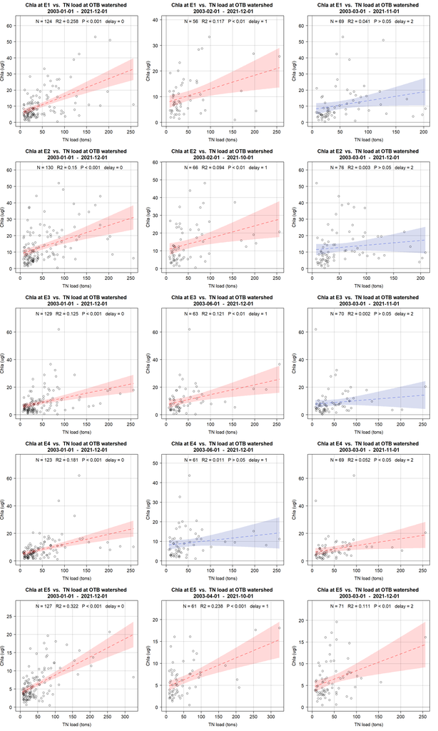

The plots below show relationships between external TN loads and chlorophyll-a concentrations within the three OTB sub-segments compartmentalized by the Courtney Campbell, Howard Frankland, and Gandy Blvd causeways/bridges, using water quality data collected by EPC at fixed monitoring locations between 2000 and 2021. The three OTB compartments span the three rows, and the three columns pertain to delays of zero, one, and two months. All three OTB compartments show significant positive correlations at each delay, with a maximum R2 value of 0.38. In each case the data exhibit substantial scatter around the regression line.

```r
  par(mfrow=c(3,3))
  # assemble and re-label data for locations north of Courtney Campbell
  epc1 <- epcwq2[ which( epcwq2$site %in% c(46,47,60,61,62,64) ), ]
  epc1$site <- "North CC"
  # models
  epc1_load_Chla_0 <- OTB_corr( x = loads, y = epc1, 'TN load', 'Chla',
                                'OTB watershed', 'North CC', delay = 0 )
  epc1_load_Chla_1 <- OTB_corr( x = loads, y = epc1, 'TN load', 'Chla',
                                'OTB watershed', 'North CC', delay = 1 )
  epc1_load_Chla_2 <- OTB_corr( x = loads, y = epc1, 'TN load', 'Chla',
                                'OTB watershed', 'North CC', delay = 2 )

  # assemble and re-label data for locations between Frankland & Campbell
  epc2 <- epcwq2[ which( epcwq2$site %in% c(40,41,42,63,65,66) ), ]
  epc2$site <- "HF-CC"
  # models
  epc2_load_Chla_0 <- OTB_corr( x = loads, y = epc2, 'TN load', 'Chla',
                                'OTB watershed', 'HF-CC', delay = 0 )
  epc2_load_Chla_1 <- OTB_corr( x = loads, y = epc2, 'TN load', 'Chla',
                                'OTB watershed', 'HF-CC', delay = 1 )
  epc2_load_Chla_2 <- OTB_corr( x = loads, y = epc2, 'TN load', 'Chla',
                                'OTB watershed', 'HF-CC', delay = 2 )

  # assemble and re-label data for locations between Gandy & Frankland
  epc3 <- epcwq2[ which( epcwq2$site %in% c(38,50,51,67) ), ]
  epc3$site <- "GB-HF"
  # models
  epc3_load_Chla_0 <- OTB_corr( x = loads, y = epc3, 'TN load', 'Chla',
                                'OTB watershed', 'GB-HF', delay = 0 )
  epc3_load_Chla_1 <- OTB_corr( x = loads, y = epc3, 'TN load', 'Chla',
                                'OTB watershed', 'GB-HF', delay = 1 )
  epc3_load_Chla_2 <- OTB_corr( x = loads, y = epc3, 'TN load', 'Chla',
                                'OTB watershed', 'GB-HF', delay = 2 )
```

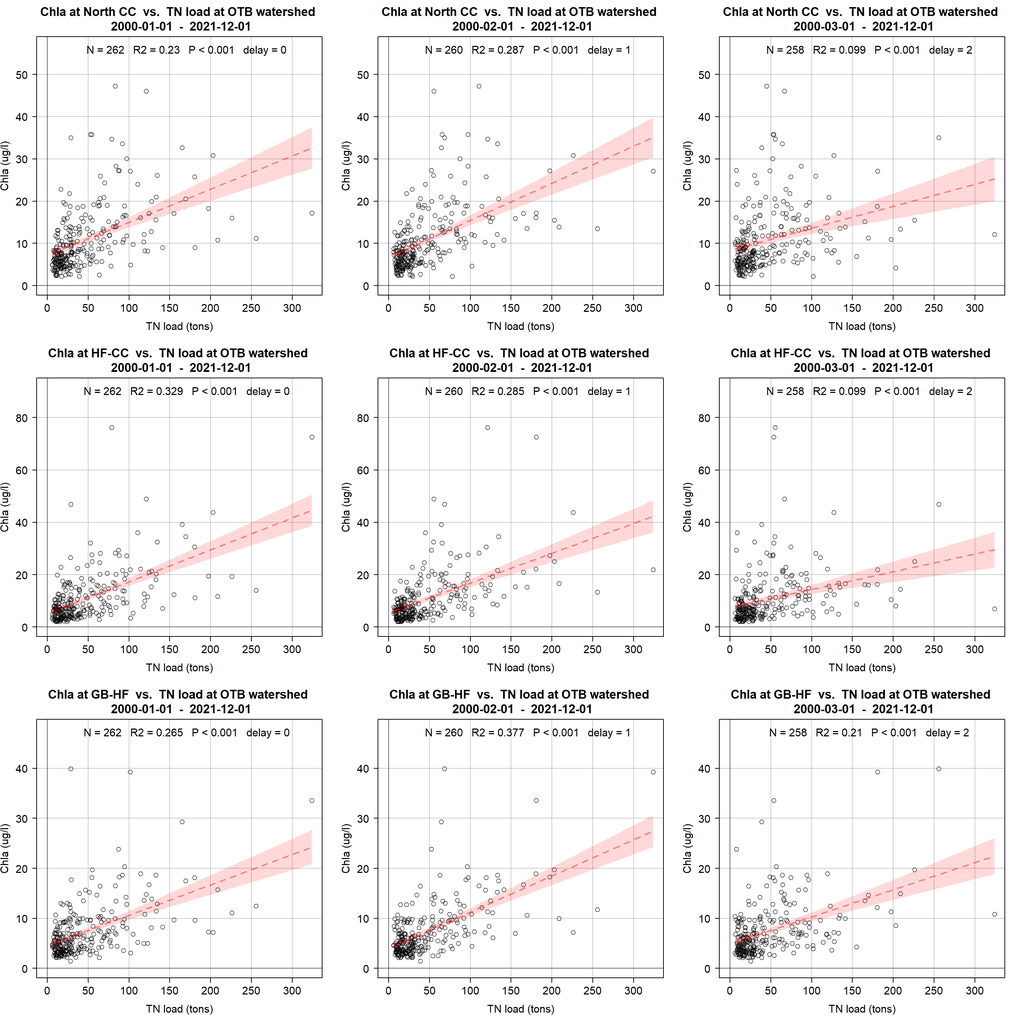

top

## Chlorophyll and light

The plots below show relationships between chlorophyll-a concentrations and Secchi depths within the three OTB sub-segments compartmentalized by the Courtney Campbell, Howard Frankland, and Gandy Blvd causeways/bridges, using data collected by EPC at fixed monitoring locations between 2000 and 2023. Following Greening & Janicki (2016), the variables are log-transformed prior to analysis. All three OTB compartments show significant negative correlations at delays of zero and one month (first and second columns), with a maximum R2 value of 0.39. The magnitudes of the slopes and the R2 values both decrease between `delay=0` and `delay=1`. And in each case, the data exhibit substantial scatter around the regression line, indicating that any given chlorophyll concentration is typically associated with a large range of Secchi values. At a delay of two months (third column), none of the OTB compartments shows a significant correlation.

```r
  par(mfrow=c(3,3))

  # models
  epc1_Chla_Secchi_0 <- OTB_corr( x = epc1, y = epc1, 'Chla', 'Secchi',
                                'North CC', log = TRUE, delay = 0 )
  epc1_Chla_Secchi_1 <- OTB_corr( x = epc1, y = epc1, 'Chla', 'Secchi',
                                'North CC', log = TRUE, delay = 1 )
  epc1_Chla_Secchi_2 <- OTB_corr( x = epc1, y = epc1, 'Chla', 'Secchi',
                                'North CC', log = TRUE, delay = 2 )

  # models
  epc2_Chla_Secchi_0 <- OTB_corr( x = epc2, y = epc2, 'Chla', 'Secchi',
                                'HF-CC', log = TRUE, delay = 0 )
  epc2_Chla_Secchi_1 <- OTB_corr( x = epc2, y = epc2, 'Chla', 'Secchi',
                                'HF-CC', log = TRUE, delay = 1 )
  epc2_Chla_Secchi_2 <- OTB_corr( x = epc2, y = epc2, 'Chla', 'Secchi',
                                'HF-CC', log = TRUE, delay = 2 )

  # models
  epc3_light_Chla_0 <- OTB_corr( x = epc3, y = epc3, 'Chla', 'Secchi',
                                'GB-HF', log = TRUE, delay = 0 )
  epc3_light_Chla_1 <- OTB_corr( x = epc3, y = epc3, 'Chla', 'Secchi',
                                'GB-HF', log = TRUE, delay = 1 )
  epc3_light_Chla_2 <- OTB_corr( x = epc3, y = epc3, 'Chla', 'Secchi',
                                'GB-HF', log = TRUE, delay = 2 )
```

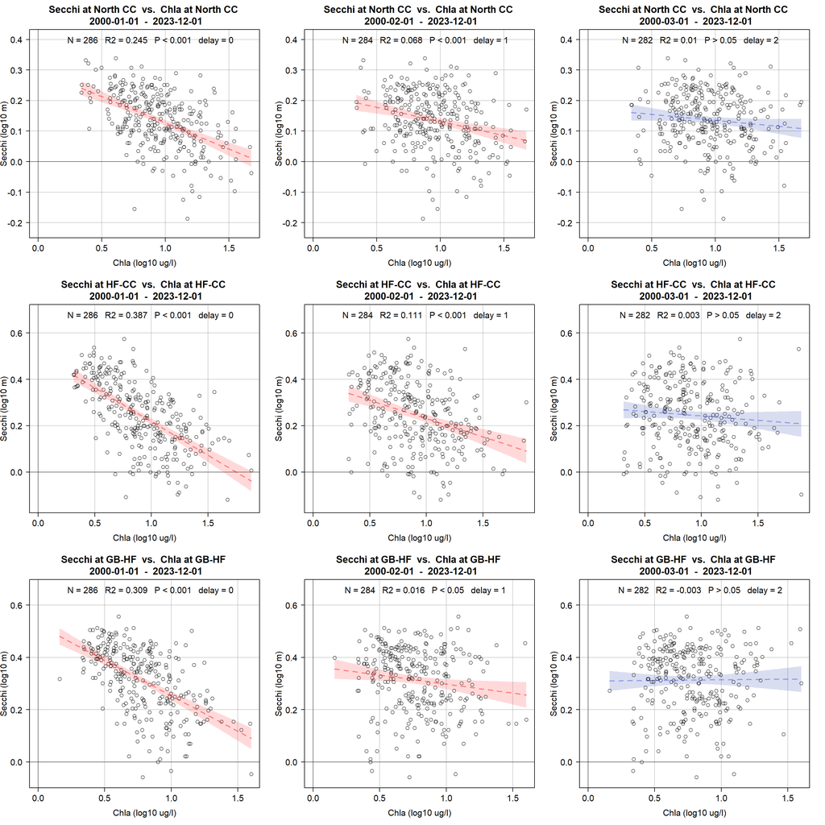

top

# Generalized Additive Models (GAMs)

Next, we explore whether nitrogen-chlorophyll and chlorophyll-Secchi relationships have changed over time across OTB sub-segments. The results indicate changes over time at some sub-segments.

## Nitrogen and chlorophyll

This section explores whether relationships between TN loads and chlorophyll concentrations at Pinellas County strata within OTB have changed over time.

### E1 (Safety Harbor / Mobbly Bay)

For stratum E1 (Safety Harbor / Mobbly Bay), we assemble the input data and specify a GAM that estimates the chlorophyll-a concentration using smooth terms for the decimal date (`decdate`), TN load (`value.x`), and their tensor product interaction. Model diagnostics indicate that the residuals are approximately Gaussian (QQ plot) and that the model had sufficient basis dimensions (k).

```r
  # join TN load data to chlorophyll data
  gamdat_E1 <- inner_join( x = pcwq2[ which( pcwq2$param=='Chla' & pcwq2$site=="E1" ), ],
                           y = loads,
                           by = 'date'
                          )
  nrow(gamdat_E1)
```

```
## [1] 128
```

```r
  # decimal date
  gamdat_E1$decdate <- gamdat_E1$date |> decimal_date()
  # fit gam
  gam1 <- gam(  log10(value.y) ~ te( decdate, value.x, k=11 ), data = gamdat_E1 )
  # model diagnostics
  par(mfrow=c(2,2))
  gam.check( gam1, rep = 1000 )
```

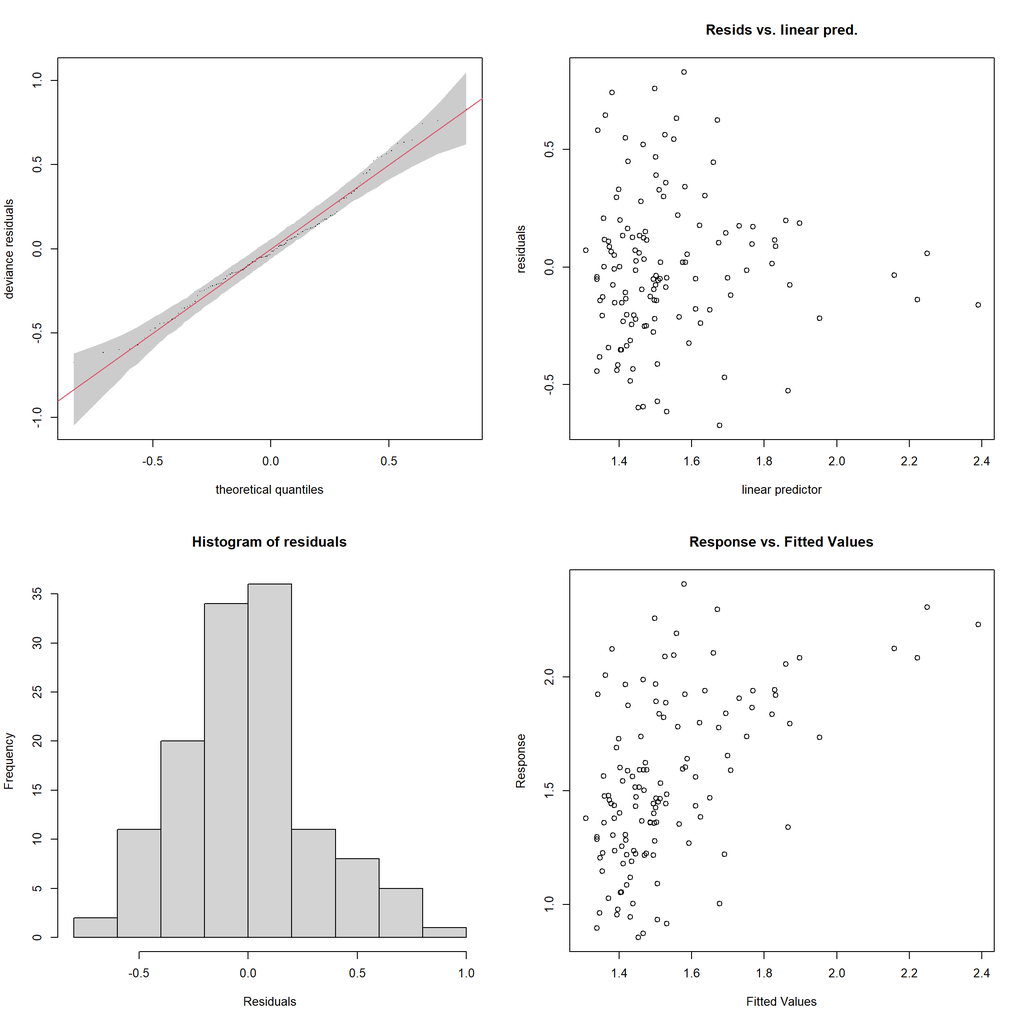

```
##
## Method: GCV   Optimizer: magic
## Smoothing parameter selection converged after 22 iterations.
## The RMS GCV score gradient at convergence was 4.369366e-08 .
## The Hessian was positive definite.
## Model rank =  121 / 121
##
## Basis dimension (k) checking results. Low p-value (k-index<1) may
## indicate that k is too low, especially if edf is close to k'.
##
##                      k' edf k-index p-value
## te(decdate,value.x) 120   3    1.07    0.80
```

```r
  summary( gam1 )
```

```
##
## Family: gaussian
## Link function: identity
##
## Formula:
## log10(value.y) ~ te(decdate, value.x, k = 11)
##
## Parametric coefficients:
##             Estimate Std. Error t value Pr(>|t|)
## (Intercept)   1.5337     0.0276   55.56   <2e-16 ***
## ---
## Signif. codes:  0 '***' 0.001 '**' 0.01 '*' 0.05 '.' 0.1 ' ' 1
##
## Approximate significance of smooth terms:
##                     edf Ref.df     F p-value
## te(decdate,value.x)   3      3 15.68  <2e-16 ***
## ---
## Signif. codes:  0 '***' 0.001 '**' 0.01 '*' 0.05 '.' 0.1 ' ' 1
##
## R-sq.(adj) =  0.257   Deviance explained = 27.5%
## GCV = 0.10067  Scale est. = 0.097528  n = 128
```

The plots below visualize the estimated `te()` coefficient surface and suggest that the association between chlorophyll concentrations and TN load (`value.x`) has not substantially changed over time (`decdate`). In the heatmap image, colors range from red (relatively low magnitude) to yellow (higher magnitude). White patches indicate gaps in the input space.

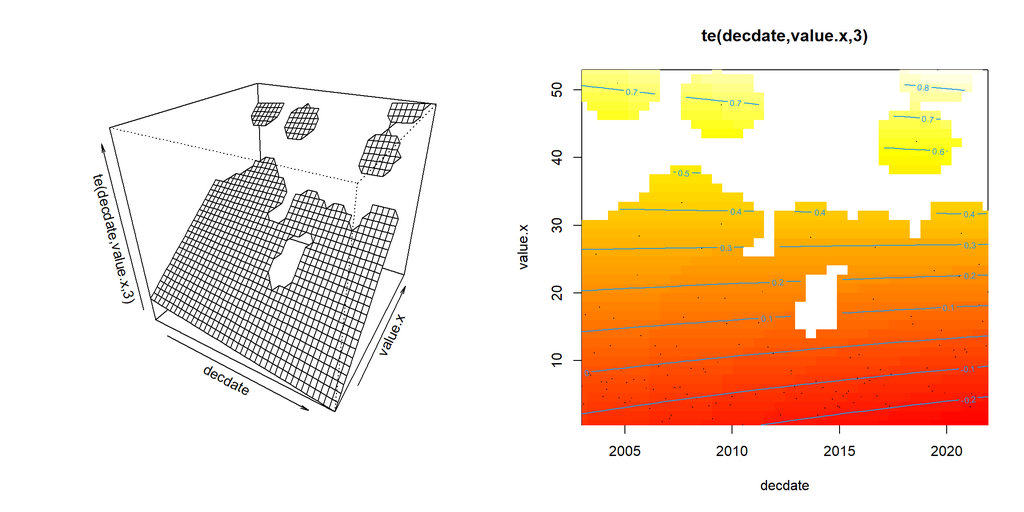

```r
  # plot smooth
  par(mfrow=c(1,2))
  plot.gam( gam1, scheme = 1)
  plot.gam( gam1, scheme = 2)
```

top

### E2 (Largo Inlet)

The model for stratum E2 (Largo Inlet) shows good diagnostics.

```r
  # join TN load data to chlorophyll data
  gamdat_E2 <- inner_join( x = pcwq2[ which( pcwq2$param=='Chla' & pcwq2$site=="E2" ), ],
                           y = loads,
                           by = 'date'
                          )
  nrow(gamdat_E2)
```

```
## [1] 133
```

```r
  # decimal date
  gamdat_E2$decdate <- gamdat_E2$date |> decimal_date()
  # fit gam
  gam2 <- gam(  log10(value.y) ~ te( decdate, value.x, k=11 ), data = gamdat_E2 )
  # model diagnostics
  par(mfrow=c(2,2))
  gam.check( gam2, rep = 1000 )
```

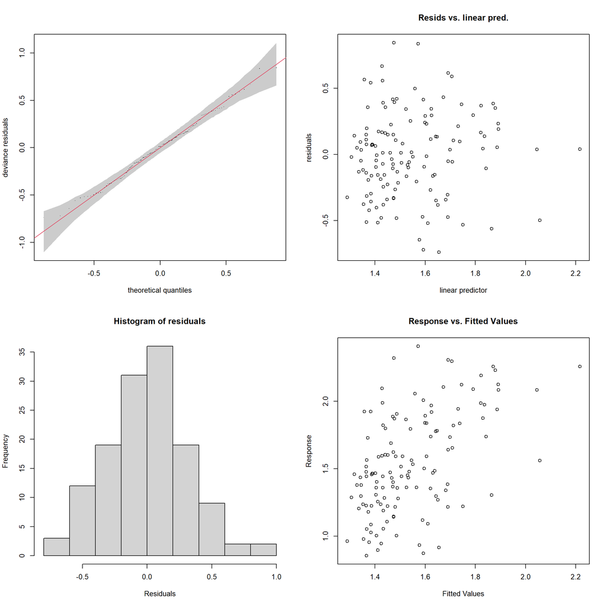

```
##
## Method: GCV   Optimizer: magic
## Smoothing parameter selection converged after 14 iterations.
## The RMS GCV score gradient at convergence was 6.447391e-08 .
## The Hessian was positive definite.
## Model rank =  121 / 121
##
## Basis dimension (k) checking results. Low p-value (k-index<1) may
## indicate that k is too low, especially if edf is close to k'.
##
##                         k'    edf k-index p-value
## te(decdate,value.x) 120.00   8.14    1.01    0.50
```

```r
  summary( gam2 )
```

```
##
## Family: gaussian
## Link function: identity
##
## Formula:
## log10(value.y) ~ te(decdate, value.x, k = 11)
##
## Parametric coefficients:
##             Estimate Std. Error t value Pr(>|t|)
## (Intercept)  1.54377    0.02855   54.07   <2e-16 ***
## ---
## Signif. codes:  0 '***' 0.001 '**' 0.01 '*' 0.05 '.' 0.1 ' ' 1
##
## Approximate significance of smooth terms:
##                       edf Ref.df     F  p-value
## te(decdate,value.x) 8.144  10.65 3.697 0.000179 ***
## ---
## Signif. codes:  0 '***' 0.001 '**' 0.01 '*' 0.05 '.' 0.1 ' ' 1
##
## R-sq.(adj) =  0.219   Deviance explained = 26.8%
## GCV = 0.11644  Scale est. = 0.10843   n = 133
```

The plots below suggest that the association between chlorophyll concentrations and TN load (`value.x`) has changed substantially over time (`decdate`) at Largo Inlet, with TN loads (`value.x`) most strongly associated with chlorophyll concentrations between about 2010 and 2015.

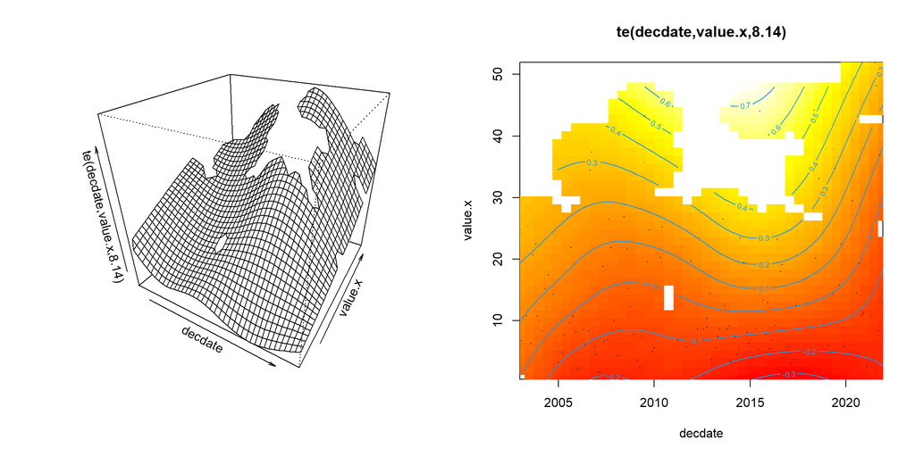

```r
  # plot smooth
  par(mfrow=c(1,2))
  plot.gam( gam2, scheme = 1)
  plot.gam( gam2, scheme = 2)
```

top

### E3 (Feather Sound)

The model for stratum E3 (Feather Sound) shows good diagnostics.

```r
  # join TN load data to chlorophyll data
  gamdat_E3 <- inner_join( x = pcwq2[ which( pcwq2$param=='Chla' & pcwq2$site=="E3" ), ],
                           y = loads,
                           by = 'date'
                          )
  nrow(gamdat_E3)
```

```
## [1] 132
```

```r
  # decimal date
  gamdat_E3$decdate <- gamdat_E3$date |> decimal_date()
  # fit gam
  gam3 <- gam(  log10(value.y) ~ te( decdate, value.x, k=11 ), data = gamdat_E3 )
  # model diagnostics
  par(mfrow=c(2,2))
  gam.check( gam3, rep = 1000 )
```

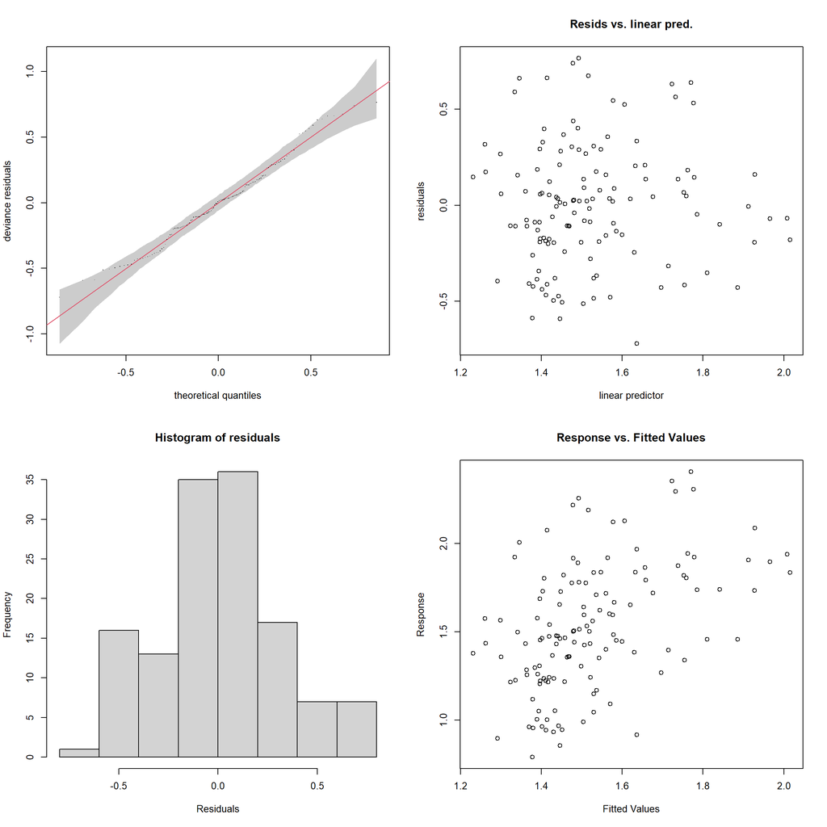

```
##
## Method: GCV   Optimizer: magic
## Smoothing parameter selection converged after 22 iterations.
## The RMS GCV score gradient at convergence was 9.880194e-08 .
## The Hessian was positive definite.
## Model rank =  121 / 121
##
## Basis dimension (k) checking results. Low p-value (k-index<1) may
## indicate that k is too low, especially if edf is close to k'.
##
##                         k'    edf k-index p-value
## te(decdate,value.x) 120.00   4.52    0.89    0.07 .
## ---
## Signif. codes:  0 '***' 0.001 '**' 0.01 '*' 0.05 '.' 0.1 ' ' 1
```

```r
  summary( gam3 )
```

```
##
## Family: gaussian
## Link function: identity
##
## Formula:
## log10(value.y) ~ te(decdate, value.x, k = 11)
##
## Parametric coefficients:
##             Estimate Std. Error t value Pr(>|t|)
## (Intercept)  1.52336    0.02802   54.36   <2e-16 ***
## ---
## Signif. codes:  0 '***' 0.001 '**' 0.01 '*' 0.05 '.' 0.1 ' ' 1
##
## Approximate significance of smooth terms:
##                       edf Ref.df     F  p-value
## te(decdate,value.x) 4.518  5.194 6.702 1.18e-05 ***
## ---
## Signif. codes:  0 '***' 0.001 '**' 0.01 '*' 0.05 '.' 0.1 ' ' 1
##
## R-sq.(adj) =  0.197   Deviance explained = 22.5%
## GCV = 0.10818  Scale est. = 0.10366   n = 132
```

The plots below suggest that the association between chlorophyll concentrations and TN load (`value.x`) has not changed substantially over time (`decdate`) at Feather Sound.

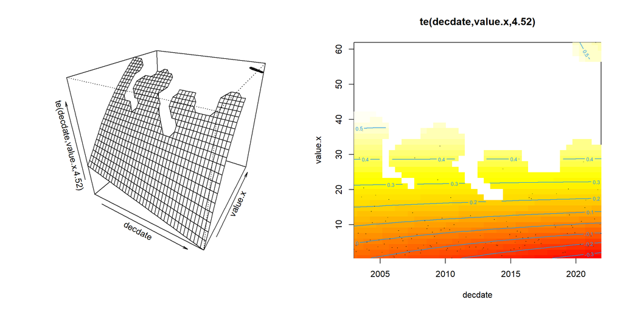

```r
  # plot smooth
  par(mfrow=c(1,2))
  plot.gam( gam3, scheme = 1)
  plot.gam( gam3, scheme = 2)
```

top

### E4 (Gateway)

The model for stratum E4 (Gateway) shows good diagnostics.

```r
  # join TN load data to chlorophyll data
  gamdat_E4 <- inner_join( x = pcwq2[ which( pcwq2$param=='Chla' & pcwq2$site=="E4" ), ],
                           y = loads,
                           by = 'date'
                          )
  nrow(gamdat_E4)
```

```
## [1] 126
```

```r
  # decimal date
  gamdat_E4$decdate <- gamdat_E4$date |> decimal_date()
  # fit gam
  gam4 <- gam(  log10(value.y) ~ te( decdate, value.x, k=11 ), data = gamdat_E4 )
  # model diagnostics
  par(mfrow=c(2,2))
  gam.check( gam4, rep = 1000 )
```

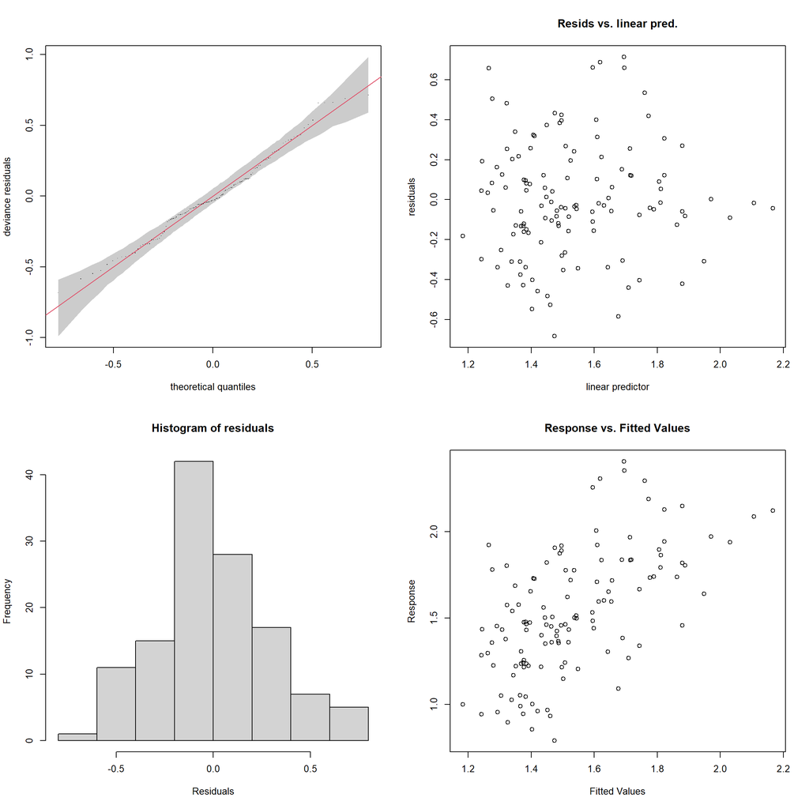

```
##
## Method: GCV   Optimizer: magic
## Smoothing parameter selection converged after 40 iterations.
## The RMS GCV score gradient at convergence was 6.314619e-06 .
## The Hessian was positive definite.
## Model rank =  121 / 121
##
## Basis dimension (k) checking results. Low p-value (k-index<1) may
## indicate that k is too low, especially if edf is close to k'.
##
##                         k'    edf k-index p-value
## te(decdate,value.x) 120.00   5.71    0.97     0.3
```

```r
  summary( gam4 )
```

```
##
## Family: gaussian
## Link function: identity
##
## Formula:
## log10(value.y) ~ te(decdate, value.x, k = 11)
##
## Parametric coefficients:
##             Estimate Std. Error t value Pr(>|t|)
## (Intercept)  1.52974    0.02616   58.47   <2e-16 ***
## ---
## Signif. codes:  0 '***' 0.001 '**' 0.01 '*' 0.05 '.' 0.1 ' ' 1
##
## Approximate significance of smooth terms:
##                       edf Ref.df     F p-value
## te(decdate,value.x) 5.712  7.127 8.513  <2e-16 ***
## ---
## Signif. codes:  0 '***' 0.001 '**' 0.01 '*' 0.05 '.' 0.1 ' ' 1
##
## R-sq.(adj) =  0.322   Deviance explained = 35.3%
## GCV = 0.091092  Scale est. = 0.08624   n = 126
```

The plots below suggest that the association between chlorophyll concentrations and TN load (`value.x`) has not changed substantially over time (`decdate`) at Gateway.

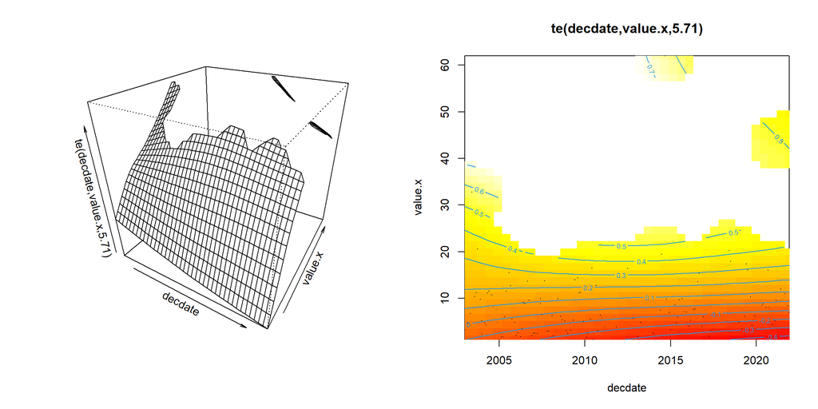

```r
  # plot smooth
  par(mfrow=c(1,2))
  plot.gam( gam4, scheme = 1)
  plot.gam( gam4, scheme = 2)
```

top

### E5 (Weedon Island)

The model for stratum E5 (Weedon Island) shows good diagnostics.

```r
  # join TN load data to chlorophyll data
  gamdat_E5 <- inner_join( x = pcwq2[ which( pcwq2$param=='Chla' & pcwq2$site=="E5" ), ],
                           y = loads,
                           by = 'date'
                          )
  nrow(gamdat_E5)
```

```
## [1] 129
```

```r
  # decimal date
  gamdat_E5$decdate <- gamdat_E5$date |> decimal_date()
  # fit gam
  gam5 <- gam(  log10(value.y) ~ te( decdate, value.x, k=11 ), data = gamdat_E5 )
  # model diagnostics
  par(mfrow=c(2,2))
  gam.check( gam5, rep = 1000 )
```

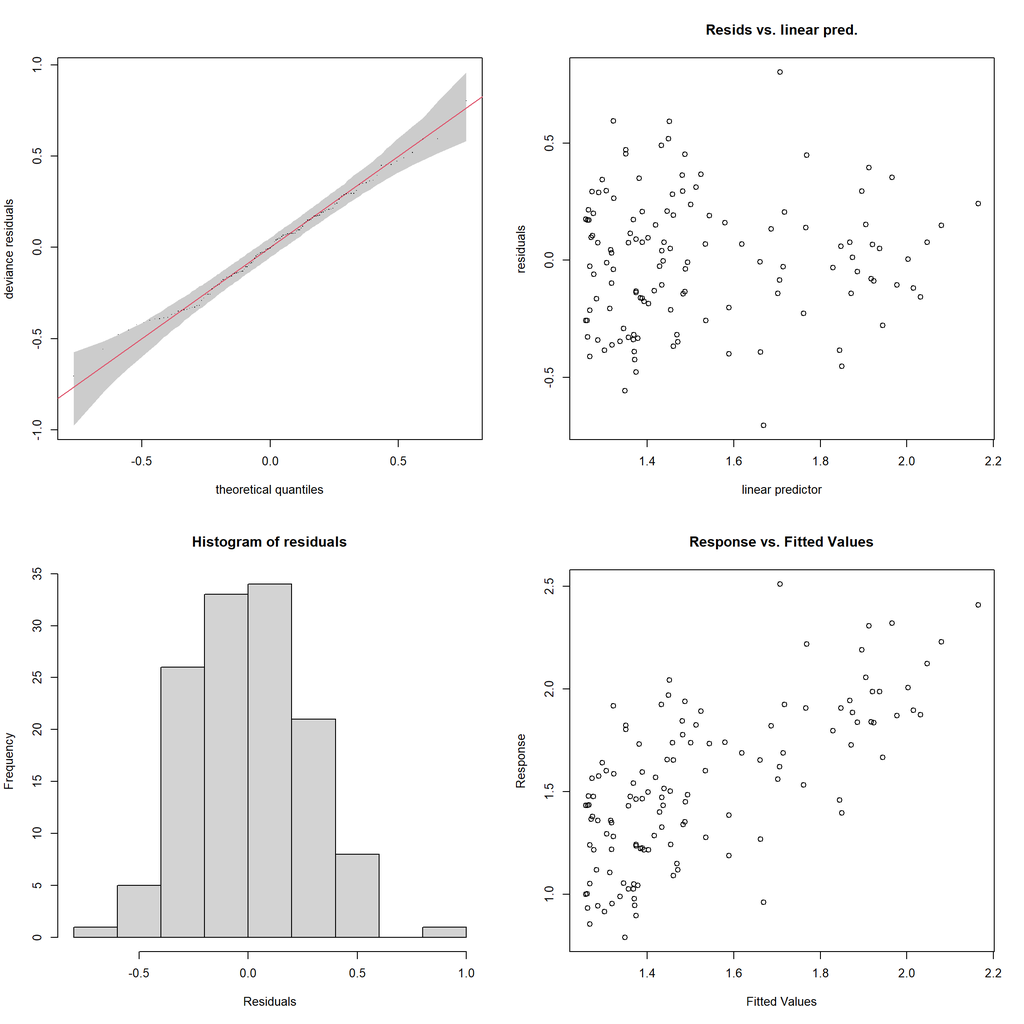

```
##
## Method: GCV   Optimizer: magic
## Smoothing parameter selection converged after 16 iterations.
## The RMS GCV score gradient at convergence was 1.948644e-06 .
## The Hessian was positive definite.
## Model rank =  121 / 121
##
## Basis dimension (k) checking results. Low p-value (k-index<1) may
## indicate that k is too low, especially if edf is close to k'.
##
##                        k'   edf k-index p-value
## te(decdate,value.x) 120.0  12.2    1.21       1
```

```r
  summary( gam5 )
```

```
##
## Family: gaussian
## Link function: identity
##
## Formula:
## log10(value.y) ~ te(decdate, value.x, k = 11)
##
## Parametric coefficients:
##             Estimate Std. Error t value Pr(>|t|)
## (Intercept)  1.51852    0.02531   60.01   <2e-16 ***
## ---
## Signif. codes:  0 '***' 0.001 '**' 0.01 '*' 0.05 '.' 0.1 ' ' 1
##
## Approximate significance of smooth terms:
##                       edf Ref.df    F p-value
## te(decdate,value.x) 12.22  15.77 5.83  <2e-16 ***
## ---
## Signif. codes:  0 '***' 0.001 '**' 0.01 '*' 0.05 '.' 0.1 ' ' 1
##
## R-sq.(adj) =  0.405   Deviance explained = 46.2%
## GCV = 0.092048  Scale est. = 0.082615  n = 129
```

The plots below suggests a possible bifurcation in the association between chlorophyll concentrations and TN load (`value.x`) at Weedon Island over time (`decdate`), for moderate to high levels of TN load.

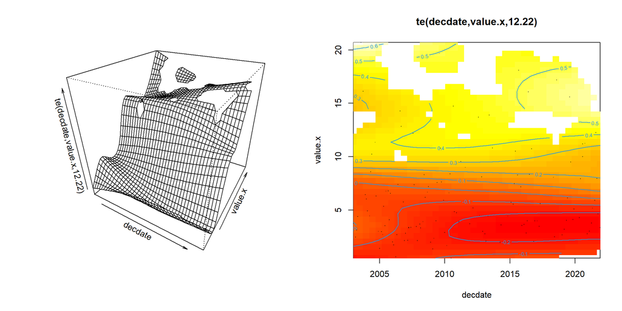

```r
  # plot smooth
  par(mfrow=c(1,2))
  plot.gam( gam5, scheme = 1)
  plot.gam( gam5, scheme = 2)
```

top

## Chlorophyll and light

This section explores whether relationships between chlorophyll concentrations and Secchi depth have changed over time across three OTB sub-segments compartmentalized by the Courtney Campbell, Howard Frankland, and Gandy Blvd causeways/bridges (EPC water quality data).

### North of Courtney Campbell

Starting with the `epc1` dataframe that we assembled for the linear model, we aggregate the data into monthly averages across EPC monitoring sites north of the Courtney Campbell causeway. The model shows good diagnostics.

```r
  # join TN load data to chlorophyll data
  epc1.chl <- epc1[ which( epc1$param=="Chla" ), ]
  epc1.chl <- epc1.chl |> group_by(date) |> summarize(value=mean(value)) |> as.data.frame()
  epc1.sec <- epc1[ which( epc1$param=="Secchi" ), ]
  epc1.sec <- epc1.sec |> group_by(date) |> summarize(value=mean(value)) |> as.data.frame()
  gamdat_epc1 <- inner_join( x = epc1.chl, y = epc1.sec, by = 'date' )
  nrow(gamdat_E2)
```

```
## [1] 133
```

```r
  # decimal date
  gamdat_epc1$decdate <- gamdat_epc1$date |> decimal_date()
  # fit gam
  gam6 <- gam(  log10(value.y) ~ te( decdate, value.x, k=11 ), data = gamdat_epc1 )
  # model diagnostics
  par(mfrow=c(2,2))
  gam.check( gam6, rep = 1000 )
```

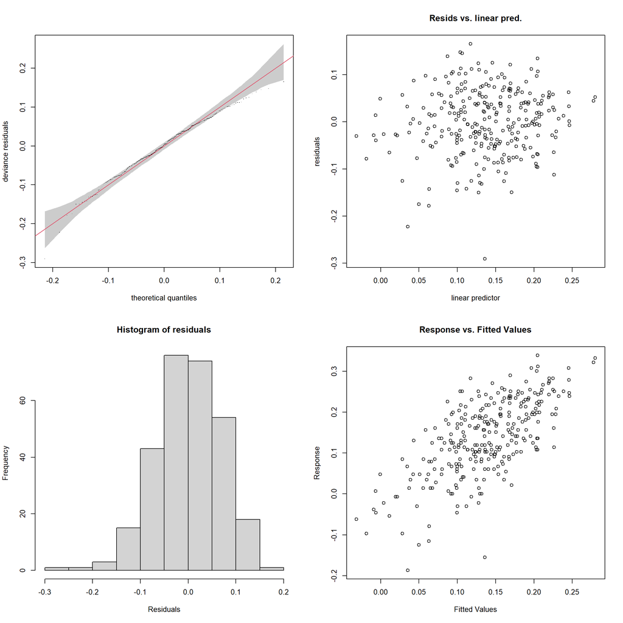

```
##
## Method: GCV   Optimizer: magic
## Smoothing parameter selection converged after 10 iterations.
## The RMS GCV score gradient at convergence was 5.242894e-08 .
## The Hessian was positive definite.
## Model rank =  121 / 121
##
## Basis dimension (k) checking results. Low p-value (k-index<1) may
## indicate that k is too low, especially if edf is close to k'.
##
##                        k'   edf k-index p-value
## te(decdate,value.x) 120.0  34.3       1    0.54
```

```r
  summary( gam6 )
```

```
##
## Family: gaussian
## Link function: identity
##
## Formula:
## log10(value.y) ~ te(decdate, value.x, k = 11)
##
## Parametric coefficients:
##             Estimate Std. Error t value Pr(>|t|)
## (Intercept) 0.137113   0.004349   31.53   <2e-16 ***
## ---
## Signif. codes:  0 '***' 0.001 '**' 0.01 '*' 0.05 '.' 0.1 ' ' 1
##
## Approximate significance of smooth terms:
##                       edf Ref.df     F p-value
## te(decdate,value.x) 34.28  43.64 4.206  <2e-16 ***
## ---
## Signif. codes:  0 '***' 0.001 '**' 0.01 '*' 0.05 '.' 0.1 ' ' 1
##
## R-sq.(adj) =  0.378   Deviance explained = 45.3%
## GCV = 0.0061712  Scale est. = 0.0054099  n = 286
```

The plots below visualize the estimated `te()` coefficient surface and suggest that the association between Secchi depth and chlorophyll concentration (`value.x`) has changed substantially over time (`decdate`). Redder areas in the heatmap indicate time periods when increased chlorophyll concentrations were more strongly associated with reduced water clarity.

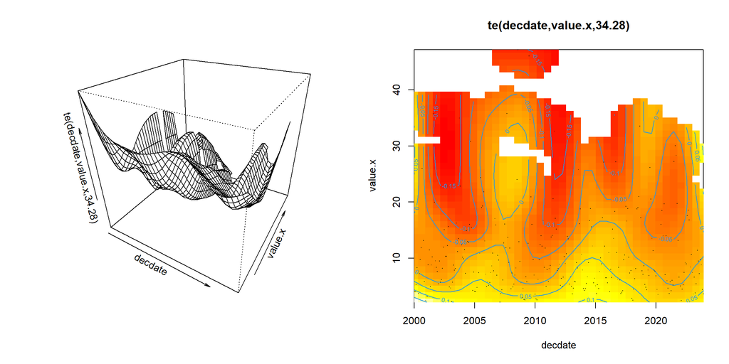

```r
  # plot smooth
  par(mfrow=c(1,2))
  plot.gam( gam6, scheme = 1)
  plot.gam( gam6, scheme = 2)
```

top

### Between the Frankland Bridge and Courtney Campbell

Starting with the `epc2` dataframe that we assembled for the linear model, we aggregate the data into monthly averages across EPC monitoring sites between the Frankland bridge and the Courtney Campbell causeway. The model shows good diagnostics.

```r
 # join TN load data to chlorophyll data
 epc2.chl <- epc2[ which( epc2$param=="Chla" ), ]
 epc2.chl <- epc2.chl |> group_by(date) |> summarize(value=mean(value)) |> as.data.frame()
 epc2.sec <- epc2[ which( epc2$param=="Secchi" ), ]
 epc2.sec <- epc2.sec |> group_by(date) |> summarize(value=mean(value)) |> as.data.frame()
 gamdat_epc2 <- inner_join( x = epc2.chl, y = epc2.sec, by = 'date' )
 nrow(gamdat_E2)
```

```
## [1] 133
```

```r
 # decimal date
 gamdat_epc2$decdate <- gamdat_epc2$date |> decimal_date()
 # fit gam
 gam7 <- gam(  log10(value.y) ~ te( decdate, value.x, k=11 ), data = gamdat_epc2 )
 # model diagnostics
 par(mfrow=c(2,2))
 gam.check( gam7, rep = 1000 )
```

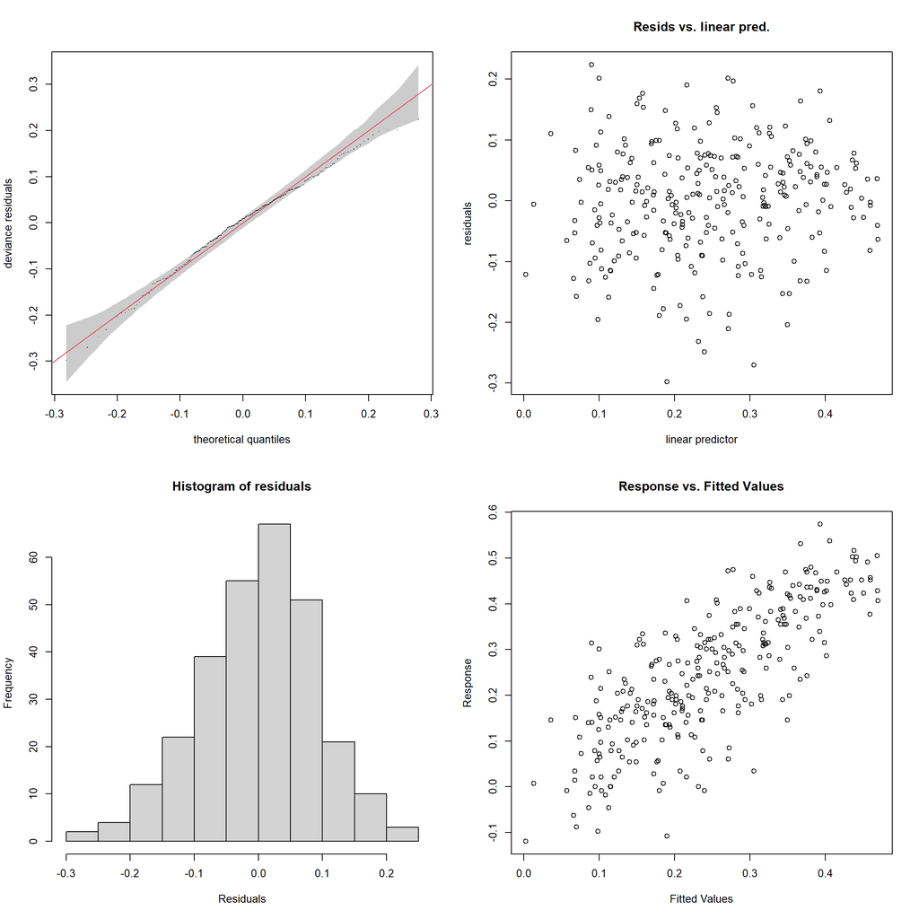

```
##
## Method: GCV   Optimizer: magic
## Smoothing parameter selection converged after 6 iterations.
## The RMS GCV score gradient at convergence was 2.899923e-06 .
## The Hessian was positive definite.
## Model rank =  121 / 121
##
## Basis dimension (k) checking results. Low p-value (k-index<1) may
## indicate that k is too low, especially if edf is close to k'.
##
##                        k'   edf k-index p-value
## te(decdate,value.x) 120.0  30.4    1.03    0.72
```

```r
 summary( gam7 )
```

```
##
## Family: gaussian
## Link function: identity
##
## Formula:
## log10(value.y) ~ te(decdate, value.x, k = 11)
##
## Parametric coefficients:
##             Estimate Std. Error t value Pr(>|t|)
## (Intercept) 0.245438   0.005696   43.09   <2e-16 ***
## ---
## Signif. codes:  0 '***' 0.001 '**' 0.01 '*' 0.05 '.' 0.1 ' ' 1
##
## Approximate significance of smooth terms:
##                       edf Ref.df    F p-value
## te(decdate,value.x) 30.38   38.1 9.93  <2e-16 ***
## ---
## Signif. codes:  0 '***' 0.001 '**' 0.01 '*' 0.05 '.' 0.1 ' ' 1
##
## R-sq.(adj) =  0.568   Deviance explained = 61.4%
## GCV = 0.010424  Scale est. = 0.0092805  n = 286
```

The plots below suggest that the association between Secchi depth and chlorophyll concentration (`value.x`) has changed substantially over time (`decdate`) at this sub-segment. Redder areas in the heatmap indicate time periods when increased chlorophyll concentrations were more strongly associated with reduced water clarity. Although the heatmap indicates gaps in some high-chlorophyll areas of the input space, the temporal pattern in these results noticeably resembles those of the previous model (`gam6`). Nonetheless, comparing the outputs of the `gam6` and `gam7` models is not straightforward as the estimated intercepts differ in magnitude between models (see `summary(...)` outputs), as do the scales of the axes of the coefficient surface plots. Further interpretation and comparison of these results can be pursued at a later phase of the project.

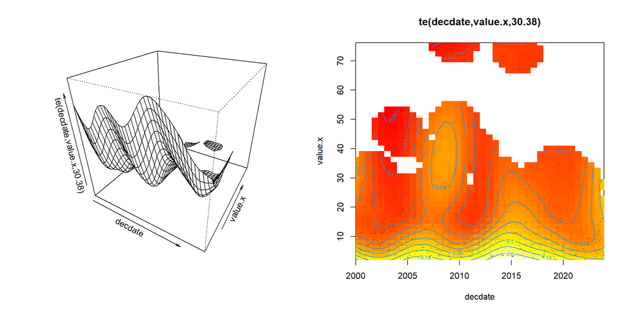

```r
  # plot smooth
  par(mfrow=c(1,2))
  plot.gam( gam7, scheme = 1)
  plot.gam( gam7, scheme = 2)
```

top

### Between Gandy Blvd and the Frankland Bridge

Starting with the `epc3` dataframe that we assembled for the linear model, we aggregate the data into monthly averages across EPC monitoring sites between Gandy Blvd and the Frankland Bridge. The model shows good diagnostics.

```r
  # join TN load data to chlorophyll data
  epc3.chl <- epc3[ which( epc3$param=="Chla" ), ]
  epc3.chl <- epc3.chl |> group_by(date) |> summarize(value=mean(value)) |> as.data.frame()
  epc3.sec <- epc3[ which( epc3$param=="Secchi" ), ]
  epc3.sec <- epc3.sec |> group_by(date) |> summarize(value=mean(value)) |> as.data.frame()
  gamdat_epc3 <- inner_join( x = epc3.chl, y = epc3.sec, by = 'date' )
  nrow(gamdat_E2)
```

```
## [1] 133
```

```r
  # decimal date
  gamdat_epc3$decdate <- gamdat_epc3$date |> decimal_date()
  # fit gam
  gam8 <- gam(  log10(value.y) ~ te( decdate, value.x, k=11 ), data = gamdat_epc3 )
  # model diagnostics
  par(mfrow=c(2,2))
  gam.check( gam8, rep = 1000 )
```

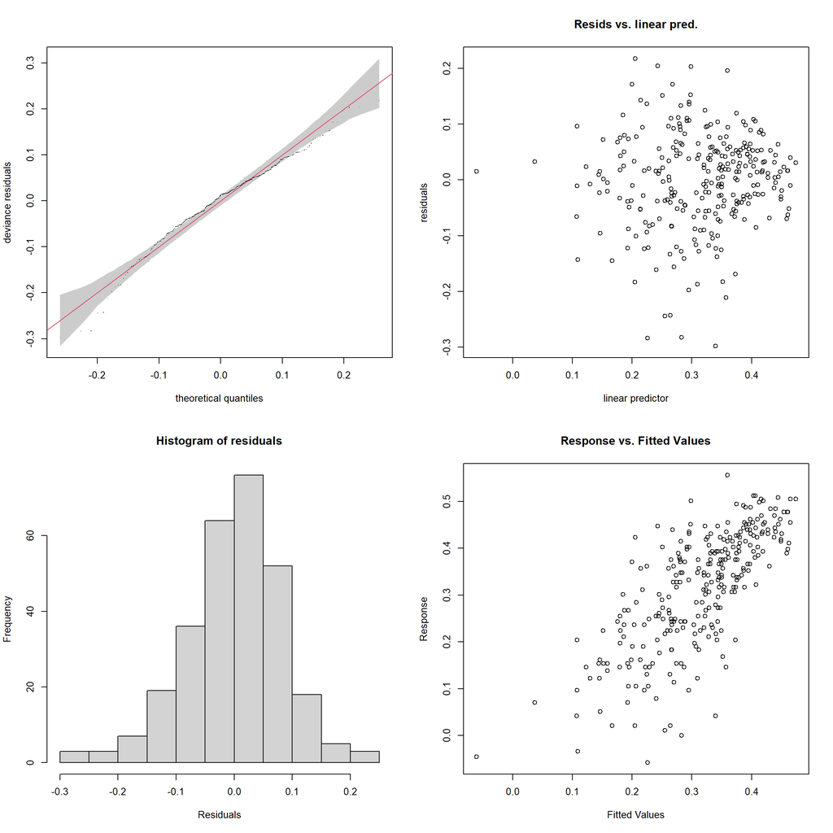

```
##
## Method: GCV   Optimizer: magic
## Smoothing parameter selection converged after 6 iterations.
## The RMS GCV score gradient at convergence was 1.419915e-06 .
## The Hessian was positive definite.
## Model rank =  121 / 121
##
## Basis dimension (k) checking results. Low p-value (k-index<1) may
## indicate that k is too low, especially if edf is close to k'.
##
##                        k'   edf k-index p-value
## te(decdate,value.x) 120.0  22.9    1.05    0.78
```

```r
  summary( gam8 )
```

```
##
## Family: gaussian
## Link function: identity
##
## Formula:
## log10(value.y) ~ te(decdate, value.x, k = 11)
##
## Parametric coefficients:
##             Estimate Std. Error t value Pr(>|t|)
## (Intercept) 0.313506   0.005208   60.19   <2e-16 ***
## ---
## Signif. codes:  0 '***' 0.001 '**' 0.01 '*' 0.05 '.' 0.1 ' ' 1
##
## Approximate significance of smooth terms:
##                       edf Ref.df     F p-value
## te(decdate,value.x) 22.86  29.01 10.24  <2e-16 ***
## ---
## Signif. codes:  0 '***' 0.001 '**' 0.01 '*' 0.05 '.' 0.1 ' ' 1
##
## R-sq.(adj) =  0.507   Deviance explained = 54.7%
## GCV = 0.0084648  Scale est. = 0.0077586  n = 286
```

The plots below suggest that the association between Secchi depth and chlorophyll concentration (`value.x`) has changed substantially over time (`decdate`) at this sub-segment. Comparisons of these results with those of previous models (`gam6` and `gam7`) are not straightforward and can be pursued during a later phase of the project.

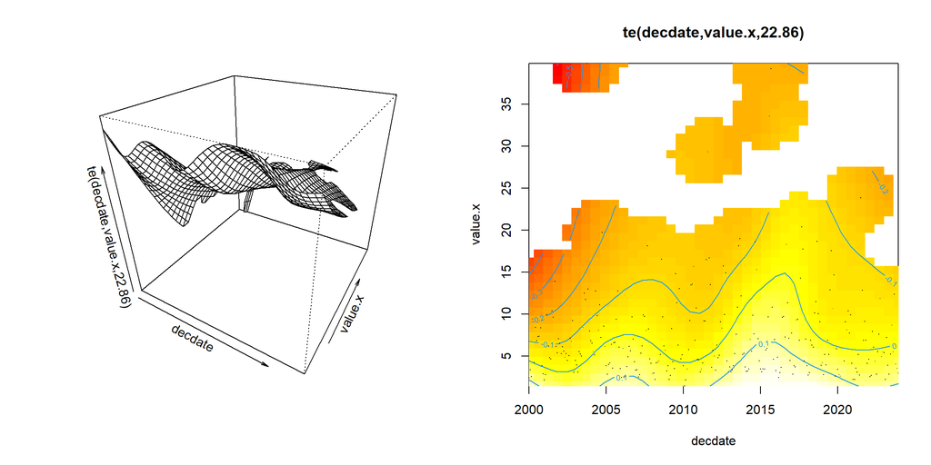

```r
  # plot smooth
  par(mfrow=c(1,2))
  plot.gam( gam8, scheme = 1)
  plot.gam( gam8, scheme = 2)
```

top

# References

Literature:

Greening H & Janicki A (2006). Toward reversal of eutrophic conditions in a subtropical Estuary: Water quality and seagrass response to nitrogen loading reductions in Tampa Bay, Florida, USA. Environmental Management 38: 163-178. http://doi.org/10.1007/s00267-005-0079-4.

Morrison G, Janicki A, Wade D, Martin J & Vargo G (1996). Estimated nitrogen fluxes and nitrogen-chlorophyll relationships in Tampa Bay, 1985-1994. Tampa Bay Area Study Group Project Reports: 128. https://digitalcommons.usf.edu/basgp_report/128.

Software:

Grolemund G, Wickham H (2011). Dates and Times Made Easy with lubridate. Journal of Statistical Software 40(3), 1-25. https://www.jstatsoft.org/v40/i03/.

R Core Team (2023). R: A Language and Environment for Statistical Computing. R Foundation for Statistical Computing, Vienna, Austria. https://www.R-project.org/.

Wickham H (2011). The Split-Apply-Combine Strategy for Data Analysis. Journal of Statistical Software 40(1): 1-29. URL https://www.jstatsoft.org/v40/i01/.

Wickham H, Francois R, Henry L, Muller K, Vaughan D (2023). dplyr: A Grammar of Data Manipulation. R package version 1.1.2, [https://CRAN.R-project.org/package=dplyr)](https://CRAN.R-project.org/package=dplyr)

Wickham H, Vaughan D, Girlich M (2023). tidyr: Tidy Messy Data. R package version 1.3.0, https://CRAN.R-project.org/package=tidyr.

Wood, SN (2017) Generalized Additive Models: An Introduction with R (2nd edition). Chapman and Hall/CRC.